# Permanova new

Olofin Daniel

2025-06-17

# Creating a new cell line for SUM to seperate (2N and 4N)

# Grouping similar treatment conditions into biologically meaningful categories:

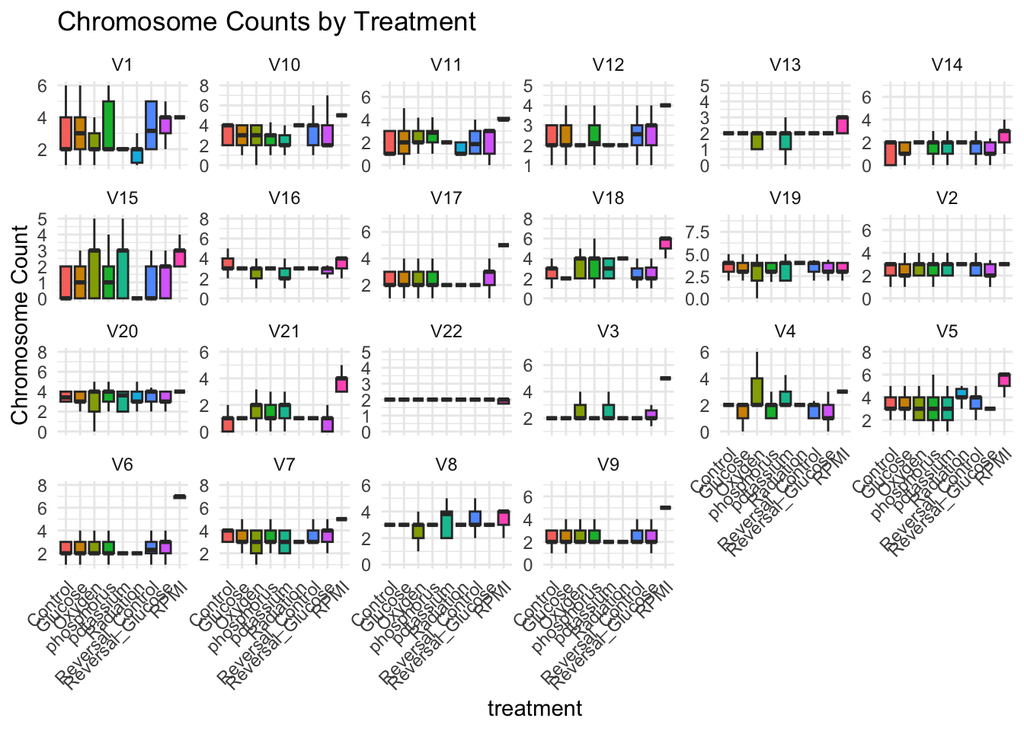

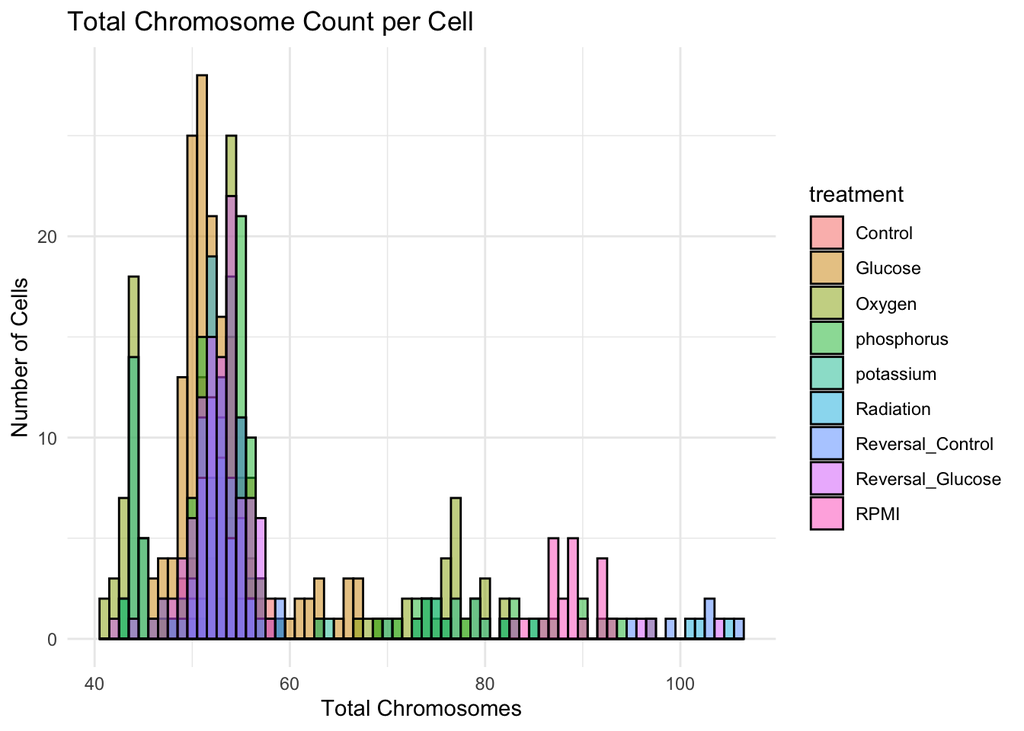

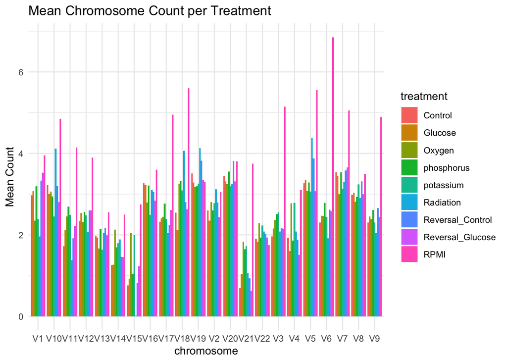

```r
# Mean per chromosome per treatment
mean_chr <- karyo_long %>%
  group_by(treatment, chromosome) %>%
  summarise(mean_count = mean(count, na.rm = TRUE), .groups = "drop")

ggplot(mean_chr, aes(x = chromosome, y = mean_count, fill = treatment)) +
  geom_bar(stat = "identity", position = "dodge") +
  theme_minimal() +
  labs(title = "Mean Chromosome Count per Treatment",
       y = "Mean Count")
```

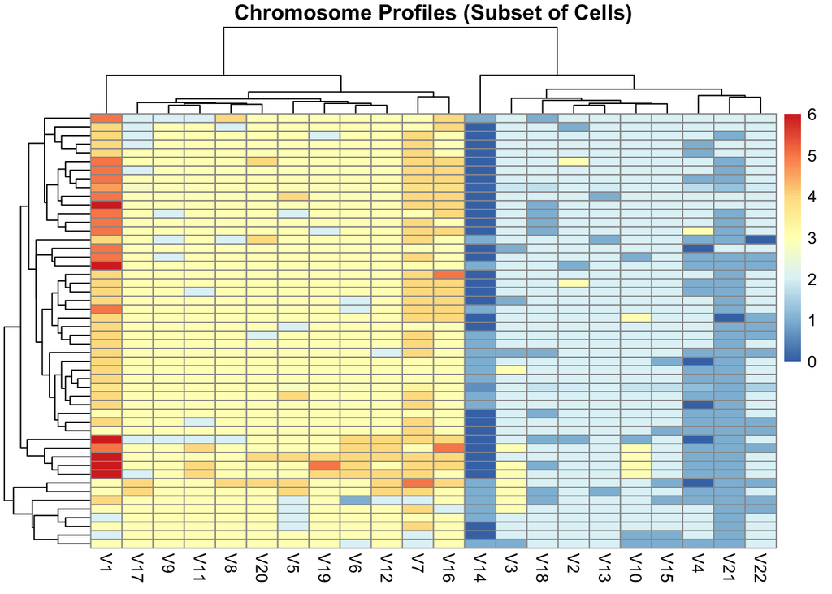

```r
library(pheatmap)

# Make a cell-by-chromosome matrix
karyo_mat <- as.matrix(karyo_df[, paste0("V", 1:22)])
rownames(karyo_mat) <- karyo_df$cloneID

# Simple heatmap
pheatmap(karyo_mat[1:50, ], cluster_rows = TRUE, cluster_cols = TRUE,
         main = "Chromosome Profiles (Subset of Cells)",
         show_rownames = FALSE)
```

- **Note:** Cell-Level PERMANOVA without Collapsing Replicates
1. You are studying how treatment affects individual cells’ karyotypes.
2. Each row represents a unique cell, preserving biological variability within flasks.
3. You can stratify by line, so that permutations are done within each cell line.
4. You retain statistical power, because you are using all the data (not just averages).

```r
# Load necessary libraries
library(vegan)
library(dplyr)
library(ggplot2)

# Step 1: Make sure your karyo_df and meta_flask align
# Let's say rownames were not preserved, rebuild them together

# Create distance matrix from a clean matrix
karyo_mat <- as.matrix(karyo_df[ , 1:22])
rownames(karyo_mat) <- karyo_df$replicate_id   # Set replicate_id as rownames

# Create metadata with matching replicate_id
meta_flask <- karyo_df[, c("replicate_id", "line", "treatment")]
rownames(meta_flask) <- seq_len(nrow(meta_flask))
rownames(karyo_mat) <- seq_len(nrow(karyo_mat))

# Now subset meta_flask to match the distance matrix
meta_flask <- meta_flask[rownames(karyo_mat), ]

# Recreate distance matrix and run adonis2
dist_flask <- dist(karyo_mat)

# Check alignment
stopifnot(all(rownames(meta_flask) == attr(dist_flask, "Labels")))

# Step 2: Run adonis2
library(vegan)
adonis2(
  formula = dist_flask ~ line + treatment,
  data = meta_flask,
  strata = meta_flask$line,
  permutations = 999
)
```

|  | Df | SumOfSqs | R2 | F | Pr(>F) |
| --- | --- | --- | --- | --- | --- |
| Model | 12 | 9337.419 | 0.6338704 | 109.9358 | 0.001 |
| Residual | 762 | 5393.383 | 0.3661296 | NA | NA |
| Total | 774 | 14730.802 | 1.0000000 | NA | NA |

**Interpretation:** A PERMANOVA was conducted to assess whether differences in karyotype profiles among individual cells were significantly associated with cell line and treatment conditions, while accounting for stratified permutation within each cell line. The overall model was highly significant (F = 109.94, $p$ = 0.001), indicating that the combined effects of cell line and treatment explain approximately 63.4% of the total variation in the chromosome features ($R^{2}$ = 0.634). This suggests that both the intrinsic characteristics of different cell lines and the external interventions from treatments contribute meaningfully to chromosomal differences observed in the data. The remaining 36.6% of the variation is unexplained by these variables and may reflect biological heterogeneity, noise, or other unmeasured factors.

```r
# Step 6: Test if treatment affects karyotype variability (dispersion)
library(vegan)

# Step 1: Check dispersion across treatment groups
dispersion <- betadisper(dist_flask, group = meta_flask$treatment)

# Step 2: Test for significance
anova(dispersion)
```

|  | Df | Sum Sq | Mean Sq | F value | Pr(>F) |
| --- | --- | --- | --- | --- | --- |
| Groups | 8 | 272.9929 | 34.124111 | 10.7638 | 2.005062e-14 |
| Residuals | 766 | 2428.4249 | 3.170268 | NA | NA |

```r
permutest(dispersion, permutations = 999)
```

```
##
## Permutation test for homogeneity of multivariate dispersions
## Permutation: free
## Number of permutations: 999
##
## Response: Distances
##            Df  Sum Sq Mean Sq      F N.Perm Pr(>F)
## Groups      8  272.99  34.124 10.764    999  0.001 ***
## Residuals 766 2428.42   3.170
## ---
## Signif. codes:  0 '***' 0.001 '**' 0.01 '*' 0.05 '.' 0.1 ' ' 1
```

**Intepretation:** The analysis of multivariate dispersions (PERMDISP) revealed a significant difference in dispersion among treatment groups (F = 10.76, p < 0.001), suggesting that variability within treatments is not uniform. This violates a key assumption of PERMANOVA, which presumes homogeneous dispersions. Consequently, although significant PERMANOVA results may indicate group differences, part of this difference could stem from heterogeneous group variances (dispersion), rather than true differences in centroid locations. Therefore, any inference about treatment effects on karyotype composition should be interpreted with caution and supported with additional visualization (e.g., NMDS/CAPscale plots) or models robust to dispersion differences, such as generalized linear models.

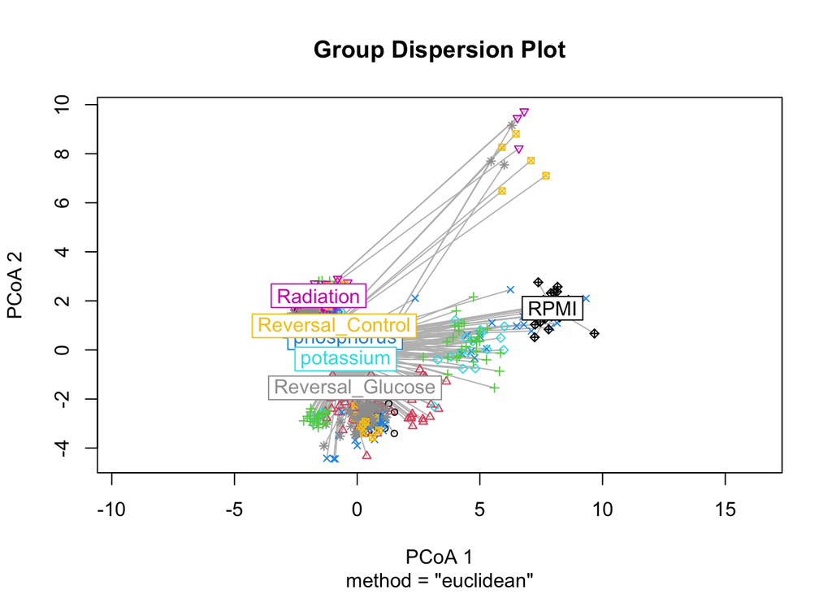

```r
plot(dispersion, hull = FALSE, main = "Group Dispersion Plot")
```

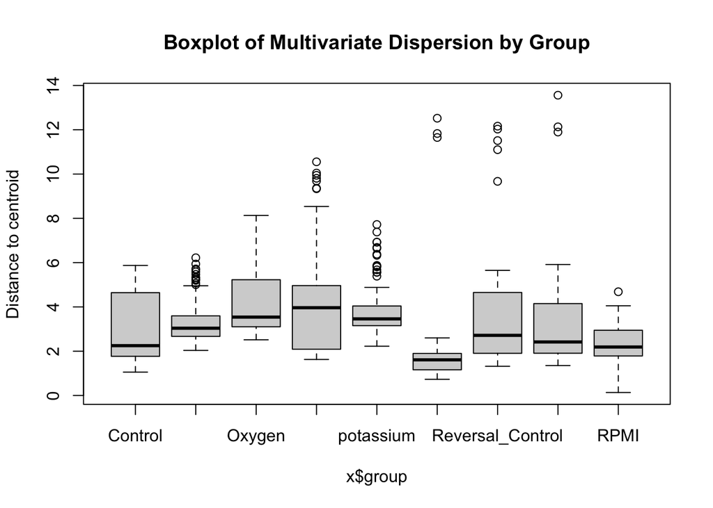

```r
boxplot(dispersion, main = "Boxplot of Multivariate Dispersion by Group")
```

- 2: GLMM for Per-Chromosome Changes

```r
library(lme4)

# Binary outcome: gain defined as >2 copies
karyo_df$gain_chr08 <- ifelse(karyo_df$V8 > 2, 1, 0)

# GLMM: treatment as fixed effect, replicate as random effect
model_chr8 <- glmer(gain_chr08 ~ treatment + (1 | replicate_id),
                    data = karyo_df, family = binomial)

summary(model_chr8)
```

```
## Generalized linear mixed model fit by maximum likelihood (Laplace
##   Approximation) [glmerMod]
##  Family: binomial  ( logit )
## Formula: gain_chr08 ~ treatment + (1 | replicate_id)
##    Data: karyo_df
##
##       AIC       BIC    logLik -2*log(L)  df.resid
##     452.8     499.4    -216.4     432.8       765
##
## Scaled residuals:
##     Min      1Q  Median      3Q     Max
## -4.9988  0.1067  0.2000  0.3134  0.7307
##
## Random effects:
##  Groups       Name        Variance Std.Dev.
##  replicate_id (Intercept) 4.798    2.19
## Number of obs: 775, groups:  replicate_id, 41
##
## Fixed effects:
##                           Estimate Std. Error z value Pr(>|z|)
## (Intercept)                 4.1392     1.5834   2.614  0.00895 **
## treatmentGlucose           -0.6901     1.8172  -0.380  0.70411
## treatmentOxygen            -2.6868     1.9029  -1.412  0.15797
## treatmentphosphorus        -1.6489     1.8523  -0.890  0.37336
## treatmentpotassium         -1.1707     2.0721  -0.565  0.57207
## treatmentRadiation         -1.8700     2.1038  -0.889  0.37407
## treatmentReversal_Control  -0.3751     2.1815  -0.172  0.86346
## treatmentReversal_Glucose  -1.4485     1.8693  -0.775  0.43840
## treatmentRPMI              -1.6835     2.8223  -0.597  0.55084
## ---
## Signif. codes:  0 '***' 0.001 '**' 0.01 '*' 0.05 '.' 0.1 ' ' 1
##
## Correlation of Fixed Effects:
##             (Intr) trtmnG trtmnO trtmntph trtmntpt trtmnR trtR_C trtR_G
## tretmntGlcs -0.861
## trtmntOxygn -0.826  0.717
## trtmntphsph -0.853  0.736  0.705
## trtmntptssm -0.743  0.660  0.626  0.637
## tretmntRdtn -0.745  0.649  0.620  0.637    0.569
## trtmntRvr_C -0.718  0.626  0.598  0.614    0.549    0.540
## trtmntRvr_G -0.842  0.730  0.698  0.719    0.636    0.631  0.608
## tretmntRPMI -0.561  0.483  0.463  0.478    0.417    0.418  0.403  0.472
```

**Interpretation:** The generalized linear mixed model assessing the impact of treatment on chromosome 08 gain revealed that no treatment condition had a statistically significant effect compared to the control. The control group showed a significantly high baseline probability of chr08 gain. Variability among replicate flasks was substantial, supporting the inclusion of random effects in the model.

## P-Adjustment (e.g., Bonferroni and Benjamini-Hochberg)

```r
# Extract p-values from model summary
p_vals <- summary(model_chr8)$coefficients[-1, "Pr(>|z|)"]  # Exclude Intercept

# Adjust p-values (Bonferroni)
p_adj_bonf <- p.adjust(p_vals, method = "bonferroni")

# Adjust p-values (Benjamini-Hochberg)
p_adj_bh <- p.adjust(p_vals, method = "BH")

# Combine results
p_table <- data.frame(
  Treatment = names(p_vals),
  Raw_P = p_vals,
  Bonferroni = p_adj_bonf,
  BH = p_adj_bh
)

p_table
```

|  | Treatment | Raw_P | Bonferroni | BH |
| --- | --- | --- | --- | --- |
| treatmentGlucose | treatmentGlucose | 0.7041135 | 1 | 0.8047011 |
| treatmentOxygen | treatmentOxygen | 0.1579727 | 1 | 0.7627630 |
| treatmentphosphorus | treatmentphosphorus | 0.3733556 | 1 | 0.7627630 |
| treatmentpotassium | treatmentpotassium | 0.5720723 | 1 | 0.7627630 |
| treatmentRadiation | treatmentRadiation | 0.3740688 | 1 | 0.7627630 |
| treatmentReversal_Control | treatmentReversal_Control | 0.8634645 | 1 | 0.8634645 |
| treatmentReversal_Glucose | treatmentReversal_Glucose | 0.4384006 | 1 | 0.7627630 |
| treatmentRPMI | treatmentRPMI | 0.5508390 | 1 | 0.7627630 |

1. Repeat the GLMM for other chromosomes (chr07, chr13, etc.)

```r
library(lme4)
library(dplyr)
library(tidyr)

# Example for chr07 and chr13
karyo_df <- karyo_df %>%
  mutate(
    gain_chr07 = ifelse(V7 > 2, 1, 0),
    gain_chr13 = ifelse(V13 > 2, 1, 0)
  )

# Fit GLMMs for chr07 and chr13
fit_chr07 <- glmer(gain_chr07 ~ treatment + (1 | replicate_id),
                   data = karyo_df, family = binomial)
fit_chr13 <- glmer(gain_chr13 ~ treatment + (1 | replicate_id),
                   data = karyo_df, family = binomial)

# Summarize models
summary(fit_chr07)
```

```
## Generalized linear mixed model fit by maximum likelihood (Laplace
##   Approximation) [glmerMod]
##  Family: binomial  ( logit )
## Formula: gain_chr07 ~ treatment + (1 | replicate_id)
##    Data: karyo_df
##
##       AIC       BIC    logLik -2*log(L)  df.resid
##     246.6     293.2    -113.3     226.6       765
##
## Scaled residuals:
##     Min      1Q  Median      3Q     Max
## -5.1159  0.0000  0.0657  0.2019  0.3827
##
## Random effects:
##  Groups       Name        Variance Std.Dev.
##  replicate_id (Intercept) 9.135    3.022
## Number of obs: 775, groups:  replicate_id, 41
##
## Fixed effects:
##                           Estimate Std. Error z value Pr(>|z|)
## (Intercept)                 23.093    154.189   0.150    0.881
## treatmentGlucose           -18.271    154.185  -0.119    0.906
## treatmentOxygen            -21.840    154.196  -0.142    0.887
## treatmentphosphorus        -17.417    154.197  -0.113    0.910
## treatmentpotassium         -20.364    154.187  -0.132    0.895
## treatmentRadiation         -18.484    154.213  -0.120    0.905
## treatmentReversal_Control   -2.519    366.506  -0.007    0.995
## treatmentReversal_Glucose  -18.470    154.195  -0.120    0.905
## treatmentRPMI               -4.743    733.012  -0.006    0.995
##
## Correlation of Fixed Effects:
##             (Intr) trtmnG trtmnO trtmntph trtmntpt trtmnR trtR_C trtR_G
## tretmntGlcs -1.000
## trtmntOxygn -1.000  1.000
## trtmntphsph -1.000  1.000  1.000
## trtmntptssm -1.000  1.000  1.000  1.000
## tretmntRdtn -1.000  1.000  1.000  1.000    1.000
## trtmntRvr_C -0.093  0.093  0.093  0.093    0.093    0.093
## trtmntRvr_G -1.000  1.000  1.000  1.000    1.000    1.000  0.093
## tretmntRPMI -0.093  0.093  0.093  0.093    0.093    0.093 -0.115  0.093
## optimizer (Nelder_Mead) convergence code: 0 (OK)
## Model is nearly unidentifiable: large eigenvalue ratio
##  - Rescale variables?
```

```r
summary(fit_chr13)
```

```
## Generalized linear mixed model fit by maximum likelihood (Laplace
##   Approximation) [glmerMod]
##  Family: binomial  ( logit )
## Formula: gain_chr13 ~ treatment + (1 | replicate_id)
##    Data: karyo_df
##
##       AIC       BIC    logLik -2*log(L)  df.resid
##     251.5     298.0    -115.7     231.5       765
##
## Scaled residuals:
##     Min      1Q  Median      3Q     Max
## -2.0932 -0.0807 -0.0489 -0.0345  5.3000
##
## Random effects:
##  Groups       Name        Variance Std.Dev.
##  replicate_id (Intercept) 6.312    2.512
## Number of obs: 775, groups:  replicate_id, 41
##
## Fixed effects:
##                           Estimate Std. Error z value Pr(>|z|)
## (Intercept)                 -19.38    2179.76  -0.009    0.993
## treatmentGlucose             12.80    2179.76   0.006    0.995
## treatmentOxygen              13.31    2179.76   0.006    0.995
## treatmentphosphorus          15.16    2179.76   0.007    0.994
## treatmentpotassium           13.42    2179.76   0.006    0.995
## treatmentRadiation           14.78    2179.76   0.007    0.995
## treatmentReversal_Control    16.47    2179.76   0.008    0.994
## treatmentReversal_Glucose    14.47    2179.76   0.007    0.995
## treatmentRPMI                19.68    2179.76   0.009    0.993
##
## Correlation of Fixed Effects:
##             (Intr) trtmnG trtmnO trtmntph trtmntpt trtmnR trtR_C trtR_G
## tretmntGlcs -1.000
## trtmntOxygn -1.000  1.000
## trtmntphsph -1.000  1.000  1.000
## trtmntptssm -1.000  1.000  1.000  1.000
## tretmntRdtn -1.000  1.000  1.000  1.000    1.000
## trtmntRvr_C -1.000  1.000  1.000  1.000    1.000    1.000
## trtmntRvr_G -1.000  1.000  1.000  1.000    1.000    1.000  1.000
## tretmntRPMI -1.000  1.000  1.000  1.000    1.000    1.000  1.000  1.000
## optimizer (Nelder_Mead) convergence code: 0 (OK)
## unable to evaluate scaled gradient
## Model failed to converge: degenerate  Hessian with 1 negative eigenvalues
```

```r
for (cell_line in unique(karyo_df$line)) {
  cat("\n\n### Cell Line:", cell_line, "###\n")
  line_df <- subset(karyo_df, line == cell_line)
  line_mat <- vegdist(as.matrix(line_df[, 1:22]), method = "manhattan")

  print(adonis2(line_mat ~ treatment,
                data = line_df,
                permutations = 999))
}
```

```
##
##
## ### Cell Line: HGC-27 ###
## Permutation test for adonis under reduced model
## Permutation: free
## Number of permutations: 999
##
## adonis2(formula = line_mat ~ treatment, data = line_df, permutations = 999)
##           Df SumOfSqs      R2      F Pr(>F)
## Model      4   1578.3 0.12227 7.7661  0.001 ***
## Residual 223  11330.0 0.87773
## Total    227  12908.3 1.00000
## ---
## Signif. codes:  0 '***' 0.001 '**' 0.01 '*' 0.05 '.' 0.1 ' ' 1
##
##
## ### Cell Line: MDAMB231 ###
## Permutation test for adonis under reduced model
## Permutation: free
## Number of permutations: 999
##
## adonis2(formula = line_mat ~ treatment, data = line_df, permutations = 999)
##          Df SumOfSqs      R2      F Pr(>F)
## Model     1    999.3 0.19734 9.8344  0.001 ***
## Residual 40   4064.6 0.80266
## Total    41   5063.9 1.00000
## ---
## Signif. codes:  0 '***' 0.001 '**' 0.01 '*' 0.05 '.' 0.1 ' ' 1
##
##
## ### Cell Line: SNU-668 ###
## Permutation test for adonis under reduced model
## Permutation: free
## Number of permutations: 999
##
## adonis2(formula = line_mat ~ treatment, data = line_df, permutations = 999)
##           Df SumOfSqs      R2      F Pr(>F)
## Model      7     6470 0.16122 10.736  0.001 ***
## Residual 391    33663 0.83878
## Total    398    40134 1.00000
```

[output cut: 11 more lines]

```
## Model     1     2.03 0.00071 0.041  0.864
## Residual 58  2874.83 0.99929
## Total    59  2876.86 1.00000
##
##
## ### Cell Line: SUM-159-4N ###
## Permutation test for adonis under reduced model
## Permutation: free
## Number of permutations: 999
##
## adonis2(formula = line_mat ~ treatment, data = line_df, permutations = 999)
##          Df SumOfSqs      R2      F Pr(>F)
## Model     1    167.5 0.02961 1.3426  0.222
## Residual 44   5490.6 0.97039
## Total    45   5658.2 1.00000
```

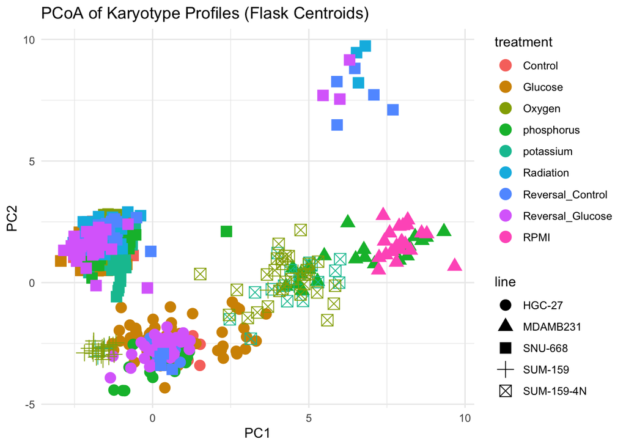

```r
# Step 7: Visualize results using PCoA (ordination plot)
pcoa <- cmdscale(dist_flask, eig = TRUE, k = 2)
pcoa_df <- data.frame(PC1 = pcoa$points[,1],
                      PC2 = pcoa$points[,2],
                      treatment = meta_flask$treatment,
                      line = meta_flask$line)

ggplot(pcoa_df, aes(x = PC1, y = PC2, color = treatment, shape = line)) +
  geom_point(size = 4) +
  theme_minimal() +
  ggtitle("PCoA of Karyotype Profiles (Flask Centroids)")
```

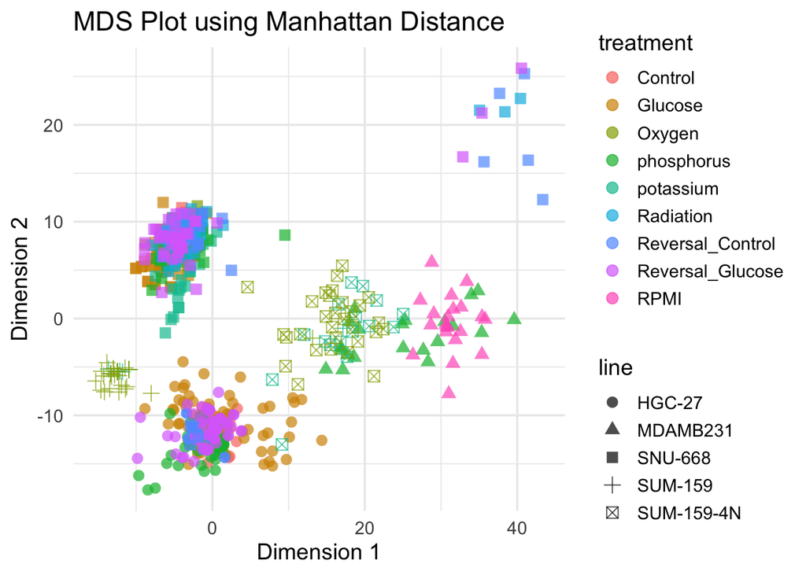

```r
# MDS using Manhattan Distance

# Load necessary libraries
library(vegan)
library(ggplot2)
library(dplyr)

# Step 1: Extract the chromosome features (V1 to V22)
karyo_matrix <- as.matrix(karyo_df[, paste0("V", 1:22)])

# Step 2: Compute Manhattan distance
dist_manhattan <- dist(karyo_matrix, method = "manhattan")

# Step 3: Perform MDS
mds_fit <- cmdscale(dist_manhattan, k = 2, eig = TRUE)

# Step 4: Prepare metadata
mds_df <- as.data.frame(mds_fit$points)
colnames(mds_df) <- c("Dim1", "Dim2")
mds_df$replicate_id <- karyo_df$replicate_id
mds_df$treatment <- karyo_df$treatment
mds_df$line <- karyo_df$line

# Step 5: Visualize
ggplot(mds_df, aes(x = Dim1, y = Dim2, color = treatment, shape = line)) +
  geom_point(alpha = 0.7, size = 3) +
  labs(title = "MDS Plot using Manhattan Distance",
       x = "Dimension 1", y = "Dimension 2") +
  theme_minimal(base_size = 14)
```